# Permutation-based multiple testing with `R` - lab 2/2

Application with R

Livio Finos

```r
# install.packages("flip")
library(flip)
```

# Seeds data

omit the `NA`s:

```r
data(seeds,package = "flip")
seeds=na.omit(seeds)
seeds
```

```
##    grp    x     y
## 9    0 6.03 12.54
## 10   0 4.20 14.81
## 11   0 4.49 16.71
## 12   0 2.00  7.53
## 13   0 2.84  7.02
## 14   0 3.88  8.09
## 15   0 2.04  5.76
## 16   0 5.48 18.01
## 17   0 2.31  8.81
## 18   0 1.90  8.17
## 19   0 1.75  6.62
## 20   0 3.02  7.69
## 24   1 3.31 18.49
## 25   1 6.56 19.20
## 26   1 3.16  9.85
## 27   1 4.07 15.83
## 28   1 2.09  6.16
## 29   1 6.72 17.58
## 30   1 3.93 19.29
## 31   1 2.56 10.77
## 32   1 8.30 18.31
## 33   1 4.21 10.56
## 34   1 1.86  9.48
## 35   1 3.09 12.54
## 36   1 5.09 18.35
## 37   1 4.08 11.84
## 38   1 3.63 11.44
## 39   1 2.61  7.66
## 40   1 5.21 12.00
```

Use a permutation methods to test if there is any difference between the two groups in `grp` on the two variables `x` and `y`:

- perform the two tests for the two variables
- Combine the two p-values using the Fisher Combining Function to test the global hypothesis
- Use a closed testing procedure to adjust the 2 p-values.

## A solution

```r
library(flip)
res=flip(.~grp,data=seeds)
```

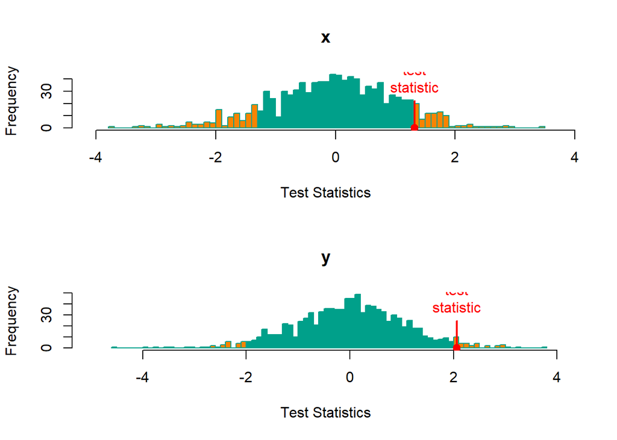

```r
hist(res)
```

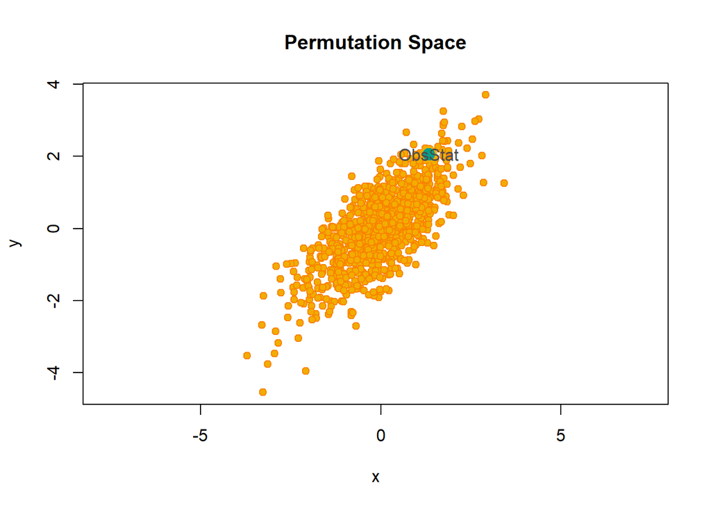

```r
plot(res)
```

```r
# Global p-value
npc(res,"Fisher")
```

```
##
##    comb.funct nVar  Stat p-value
## V1     Fisher    2 4.564  0.0890
```

```r
# adjusted p: Closed testing with Fisher combination
flip.adjust(res,"Fisher")
```

```
##
##   Test  Stat tail p-value Adjust:Fisher
## x    t 1.320   ><  0.1930        0.1930
## y    t 2.061   ><  0.0540        0.0890
```

## Rejection regions

Ask for the multivariate distribution of the p-values:

```r
res=flip(.~grp,data=seeds,flipReturn =list(permP=TRUE,permT=TRUE))
res.fisher=npc(res,"Fisher",flipReturn =list(permP=TRUE,permT=TRUE))
res.tippett=npc(res,"minP",flipReturn =list(permP=TRUE,permT=TRUE))
```

### Fisher Combining Function

We ispect the rejection regions of the two univariate tests and the one of Fisher combination.  
The intersection of each univariate test with the Fisher region defines the rejection region of a closed testing - i.e. adjusted for multiple testing.

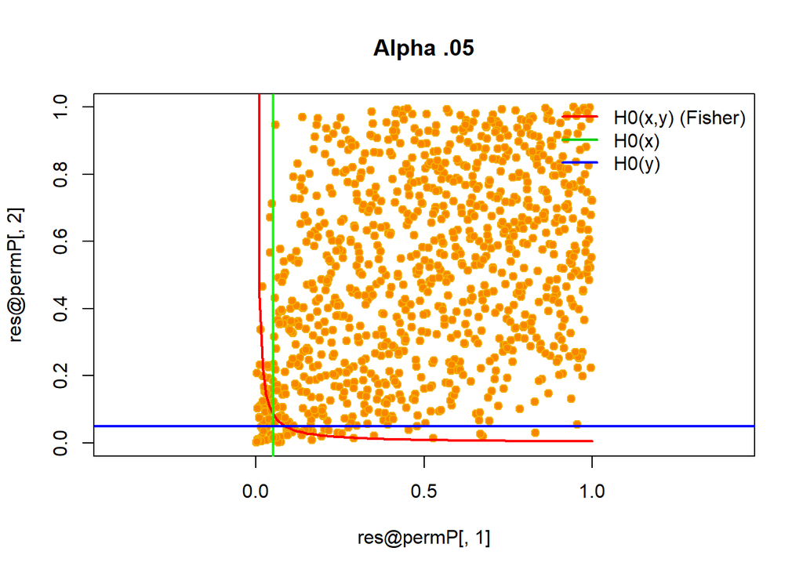

### Tippett (min-p) Combining Function

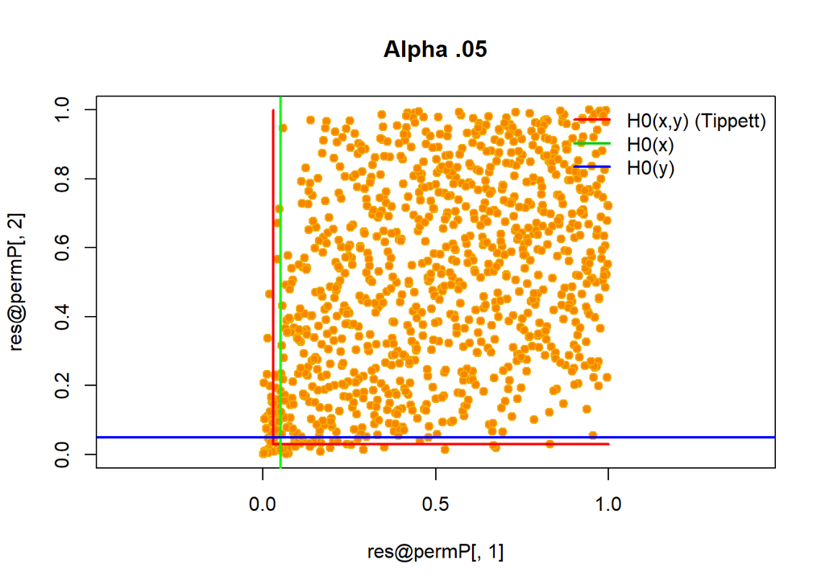

# Pharmacokinetic Study of Carbidopa

Description:  
http://webserv.jcu.edu/math//faculty/TShort/Bradstreet/part2/part2-table6.html

As part of a pharmacokinetic study, 12 healthy male subjects were allocated randomly to a three period crossover design receiving one of three graded doses (25, 50, 100 mg) of Carbidopa q8h in each treatment period. A seven day washout period separated the treatment periods. The pharmacokinetic variables AUC, Cmax, and Tmax were calculated for each subject from plasma concentrations assayed from blood samples taken at 0, 0.5, 1, 1.5, 2, 3, 4, 5, 6, 7, and 8 hours postdosing following the second dose of carbidopa on the sixth day of each treatment period.

dataset:  
http://webserv.jcu.edu/math//faculty/TShort/Bradstreet/part2/Bradp2t6.txt

Analyze the dataset without taking in account the Study Periods (which have been randomized in each subject, hence we can avoid to account for it in the analysis).

Research questions:

- Is there a dose response for AUC, Cmax, or Tmax? Overall?
- Can dose proportionality be established? (try to fit a linear model for each endpoint, then discuss the results)

## A solution

We answer to both first and second question with a single analysis: we perform a linear model (accounting for individual variability) on log transformed end-points.

```r
#Reading and make-up of the data

dati=read.table("http://webserv.jcu.edu/math//faculty/TShort/Bradstreet/part2/Bradp2t6.txt",skip = 1,header = TRUE)

dati=cbind(dati[,1],matrix(as.matrix(dati[,-1]),nrow(dati)*3,4))
colnames(dati)=c("Sub","Dose","AUC","Cmax","Tmax")

dati=as.data.frame(dati)
str(dati)
```

```
## 'data.frame':    36 obs. of  5 variables:
##  $ Sub : num  1 2 3 4 5 6 7 8 9 10 ...
##  $ Dose: num  100 25 50 50 50 25 100 25 50 25 ...
##  $ AUC : num  604 140 386 175 605 ...
##  $ Cmax: num  137 44.4 86.6 46.4 194 44.9 318 29 119 58.4 ...
##  $ Tmax: num  1.5 1 1.5 1.5 0.5 1 1 1 2 2 ...
```

```r
# transform all responses with log-transformed,
# so that a linear relationship between time and end-point indicates proportionality
dati[,3:5]=log(dati[,3:5])
```

```r
#Descriptives and plots:
summary(dati[,-1])
```

```
##       Dose             AUC             Cmax            Tmax
##  Min.   : 25.00   Min.   :4.337   Min.   :3.219   Min.   :-0.6931
##  1st Qu.: 25.00   1st Qu.:5.156   1st Qu.:3.966   1st Qu.: 0.0000
##  Median : 50.00   Median :5.886   Median :4.485   Median : 0.2027
##  Mean   : 58.33   Mean   :5.873   Mean   :4.547   Mean   : 0.2474
##  3rd Qu.:100.00   3rd Qu.:6.539   3rd Qu.:5.280   3rd Qu.: 0.6931
##  Max.   :100.00   Max.   :7.335   Max.   :5.989   Max.   : 1.0986
```

```r
by(dati[,3:5],dati$Dose,summary)
```

```
## dati$Dose: 25
##       AUC             Cmax            Tmax
##  Min.   :4.337   Min.   :3.219   Min.   :-0.6931
##  1st Qu.:4.803   1st Qu.:3.390   1st Qu.: 0.0000
##  Median :4.972   Median :3.801   Median : 0.0000
##  Mean   :5.051   Mean   :3.783   Mean   : 0.2071
##  3rd Qu.:5.289   3rd Qu.:4.022   3rd Qu.: 0.6931
##  Max.   :5.818   Max.   :4.464   Max.   : 0.6931
## --------------------------------------------------------
## dati$Dose: 50
##       AUC             Cmax            Tmax
##  Min.   :5.133   Min.   :3.837   Min.   :-0.6931
##  1st Qu.:5.670   1st Qu.:4.374   1st Qu.: 0.0000
##  Median :5.886   Median :4.484   Median : 0.2027
##  Mean   :5.815   Mean   :4.479   Mean   : 0.1689
##  3rd Qu.:5.967   3rd Qu.:4.625   3rd Qu.: 0.4055
##  Max.   :6.405   Max.   :5.268   Max.   : 1.0986
## --------------------------------------------------------
## dati$Dose: 100
##       AUC             Cmax            Tmax
##  Min.   :6.164   Min.   :4.920   Min.   :0.0000
##  1st Qu.:6.607   1st Qu.:5.229   1st Qu.:0.0000
##  Median :6.782   Median :5.412   Median :0.4055
##  Mean   :6.751   Mean   :5.378   Mean   :0.3662
##  3rd Qu.:6.922   3rd Qu.:5.515   3rd Qu.:0.6931
##  Max.   :7.335   Max.   :5.989   Max.   :1.0986
```

```r
par(mfro=c(2,2))
```

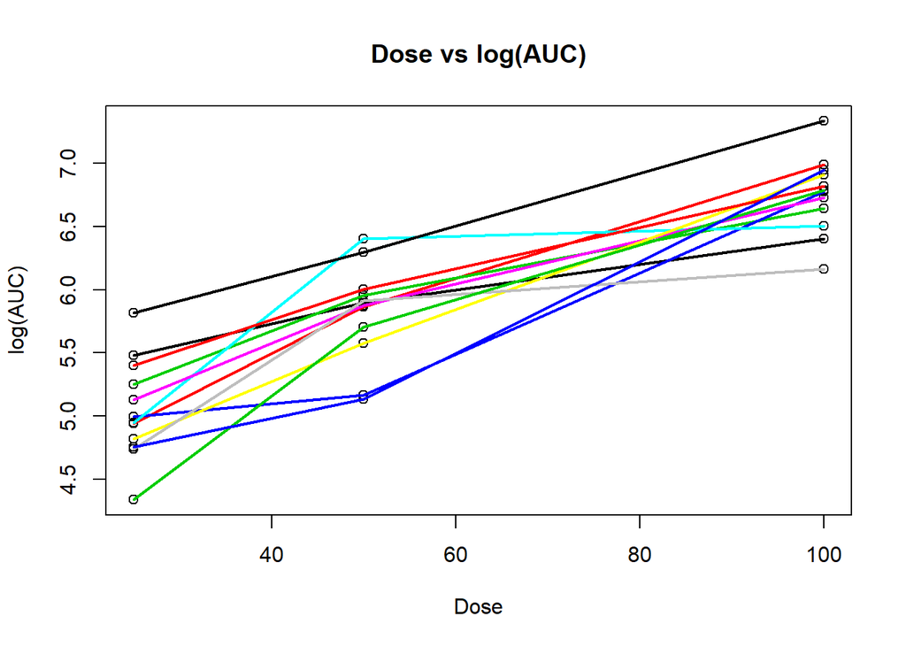

```r
plot(dati$Dose,dati$AUC,ylab="log(AUC)",xlab="Dose",main="Dose vs log(AUC)")

r=sapply(unique(dati$Sub),function(s){
  d=subset(dati,Sub==s)
  d=d[order(d$Dose),]
  lines(d$Dose,(d$AUC),col=s,lwd=2)})
```

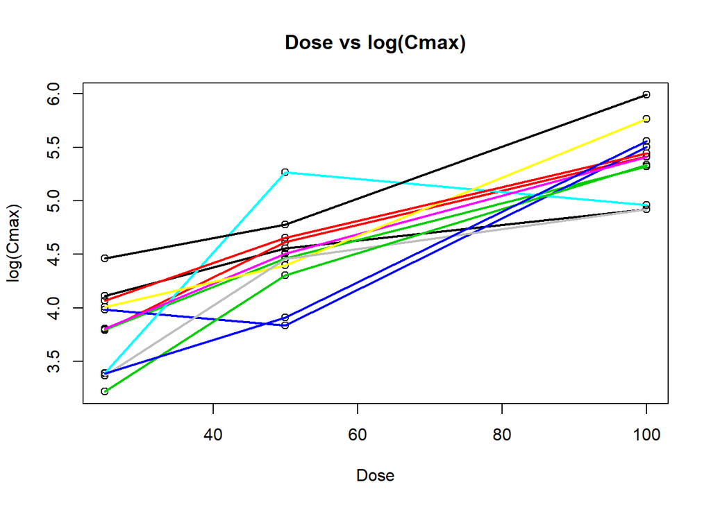

```r
plot(dati$Dose,dati$Cmax,ylab="log(Cmax)",xlab="Dose",main="Dose vs log(Cmax)")
r=sapply(unique(dati$Sub),function(s){
  d=subset(dati,Sub==s)
  d=d[order(d$Dose),]
  lines(d$Dose,(d$Cmax),col=s,lwd=2)})
```

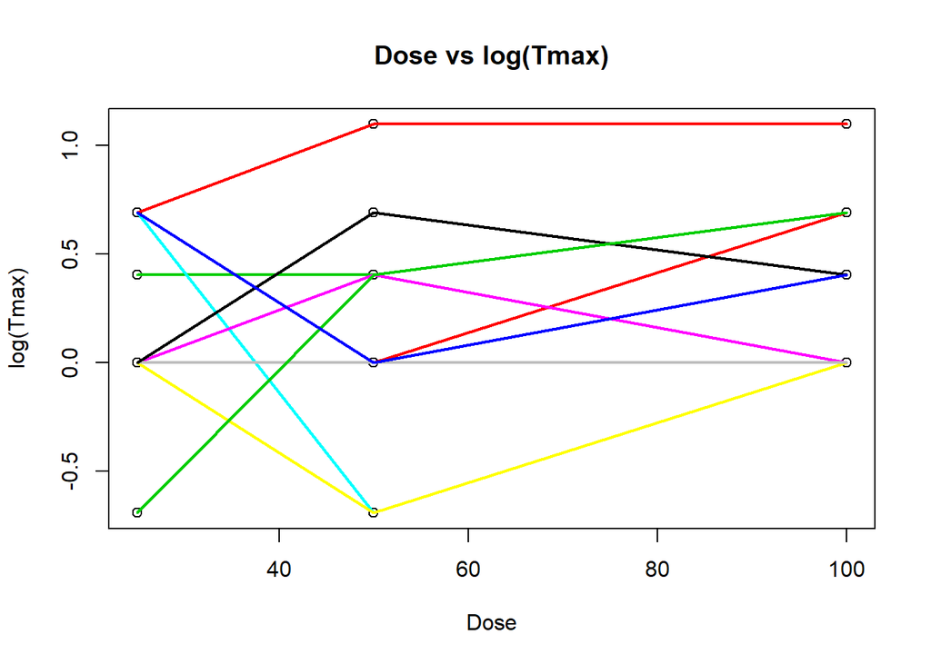

```r
plot(dati$Dose,dati$Tmax,ylab="log(Tmax)",xlab="Dose",main="Dose vs log(Tmax)")
r=sapply(unique(dati$Sub),function(s){
  d=subset(dati,Sub==s)
  d=d[order(d$Dose),]
  lines(d$Dose,(d$Tmax),col=s,lwd=2)})
```

Now the analysis: A simple solution could be:

```r
library(flip)
res=flip(.~Dose,data=dati,Strata=~Sub,statTest = "coeff")
summary(res)
```

```
##  Call:
##  flip(Y = . ~ Dose, data = dati, statTest = "coeff", Strata = ~Sub)
## 999 permutations.
##
##       Test   Stat tail p-value sig.
## AUC  coeff 0.0221   ><  0.0010  ***
## Cmax coeff 0.0208   ><  0.0010  ***
## Tmax coeff 0.0024   ><  0.2570
```

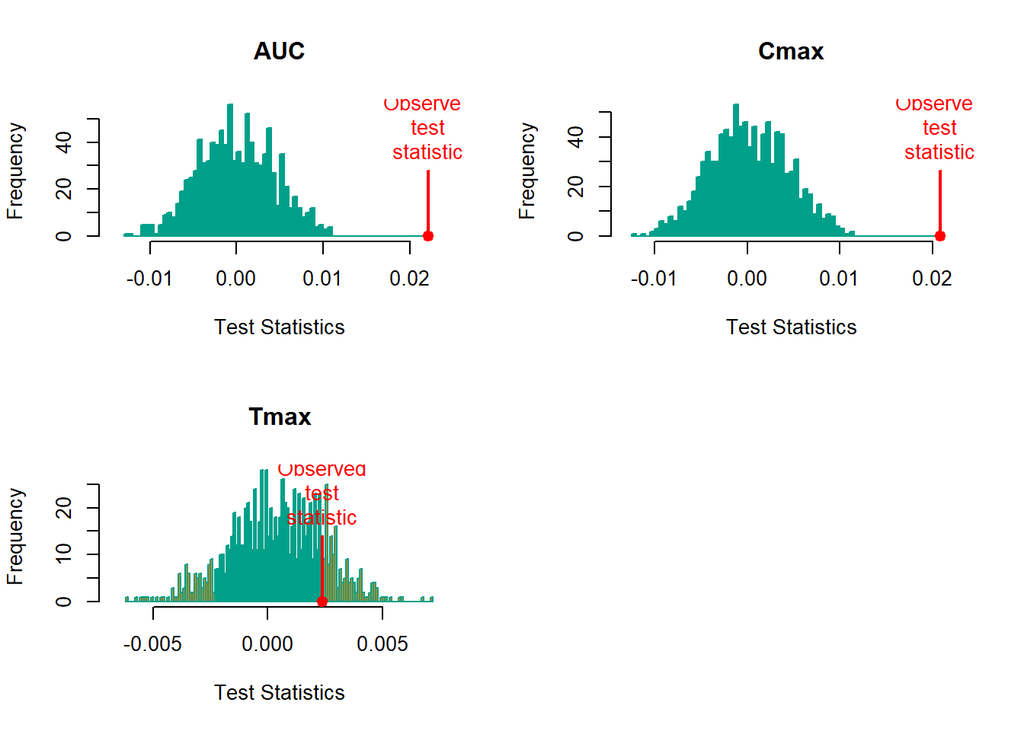

```r
#here we ask for statTest = "coeff", i.e. estimated coefficient of a linear model
hist(res)
```

Multivariate:

- Overall

```r
res=flip.adjust(res)
npc(res,"Fisher")
```

```
##
##    comb.funct nVar  Stat p-value
## V1     Fisher    3 15.17  0.0010
```

There is an effect of `Dose`, overall.

- By end-points (closed testing with max-t combininig function). Try also different methods (e.g. `method="Fisher"`) and compare the results of `method="minP"` with the one of `method="Holm"`.

```r
res=flip.adjust(res,method="holm")
res=flip.adjust(res,method="Fisher")
summary(res)
```

```
##  Call:
##  flip(Y = . ~ Dose, data = dati, statTest = "coeff", Strata = ~Sub)
## 999 permutations.
##
##       Test   Stat tail p-value Adjust:maxT Adjust:holm Adjust:Fisher sig.
## AUC  coeff 0.0221   ><  0.0010      0.0010      0.0030        0.0030   **
## Cmax coeff 0.0208   ><  0.0010      0.0010      0.0030        0.0020   **
## Tmax coeff 0.0024   ><  0.2570      0.2570      0.2570        0.2570
```

`AUC` and `Cmax` show a significant effect after correction for multiplicity, while `Tmax` does not.